# ARIMAX - Bicycles Consumption ~ Oil Price

### Dataset

For this analysis we will be using 2 datasets. The consumption expenditure on bicycles is one of the transportation analysis and is complemented by the external factor oil price. To facilitate a holistic analysis, we have merged these datasets into one.

**{r}**

```r
# Import dataset
df_bicycles <- read_csv('../data/viz_bikes.csv')

# Import dataset
df_oil_price_month <- read_csv('../data/df_oil_price_month.csv')

# Create Date
df_oil_price_month <- df_oil_price_month %>%
  mutate(date2 = make_date(year(date), month(date), 01))

# Check maximum starting date between datasets
if(min(df_bicycles$DATE) >= min(df_oil_price_month$date))
{
    min_date <- min(df_bicycles$DATE)
}else
    {
        min_date <-min(df_oil_price_month$date)
    }

# Keep relevant columns
df_oil_price_month <- df_oil_price_month %>% select('date2', 'adjusted')

# Rename columns
names(df_bicycles) <- c('DATE', 'bicycles')

# Rename columns
names(df_oil_price_month) <- c('DATE', 'oil_price')

# Filter starting date
df_bicycles <- df_bicycles %>% filter(DATE >= min_date)

# Filter starting date
df_oil_price_month <- df_oil_price_month %>% filter(DATE >= min_date)

# Combine datasets
dd <- merge(df_bicycles, df_oil_price_month, by.x = "DATE", by.y = "DATE", all = TRUE)

# Order by Date sort ascending
dd <- dd %>% arrange(DATE)

# Create the time series object
dd.ts <- ts(dd,star=decimal_date(min_date),frequency = 12)

# Show table
knitr::kable(head(dd))
```

| DATE | bicycles | oil_price |
| --- | --- | --- |
| 2000-09-01 | 3085 | 0.9740746 |
| 2000-10-01 | 3008 | 1.0199688 |
| 2000-11-01 | 3029 | 1.0546022 |
| 2000-12-01 | 3038 | 0.8429909 |
| 2001-01-01 | 3081 | 0.8954759 |
| 2001-02-01 | 3040 | 0.8555382 |

### Plot

The next step is to plot the original data. The graph below provides a separate axis for each variable considered. The first insight we obtain is the difference in units. For this reason we need to transform the *bicycle consumption* variable.

**{r}**

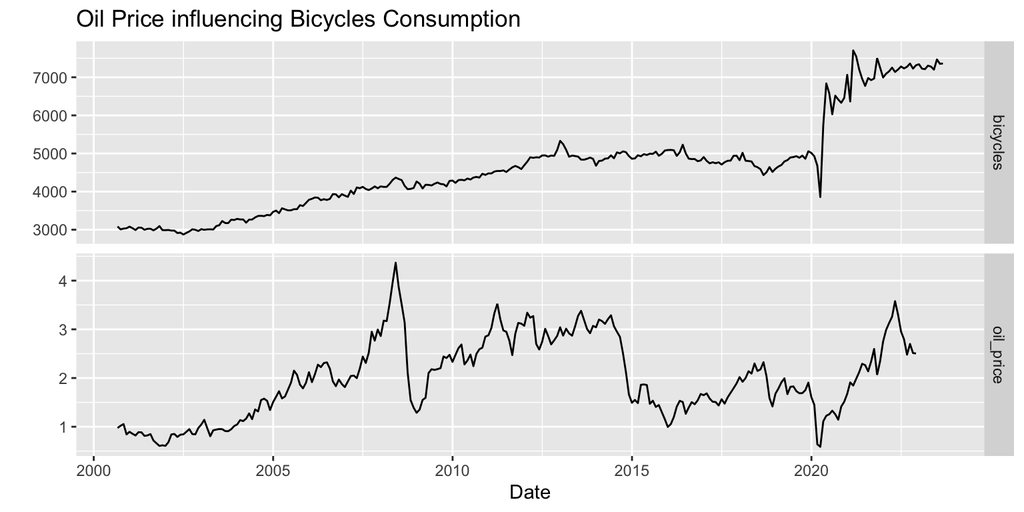

```r
# Plot time series for both variables.
autoplot(dd.ts[,c(2:3)], facets=TRUE) +
  xlab("Date") + ylab("") +
  ggtitle("Oil Price influencing Bicycles Consumption")
```

### Log Plot

**{r}**

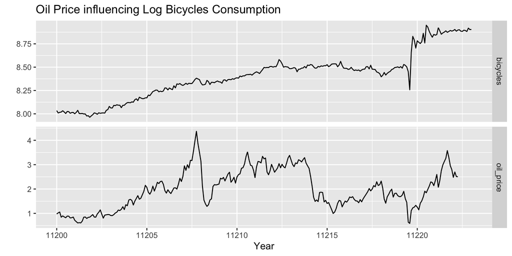

```r
lg.dd <- dd #making a copy
lg.dd$bicycles<-log(dd$bicycles)


lg.dd.ts<-ts(lg.dd,start=min_date,frequency = 12)


autoplot(lg.dd.ts[,c(2:3)], facets=TRUE) +
  xlab("Year") + ylab("") +
  ggtitle("Oil Price influencing Log Bicycles Consumption")
```

### Linear Model

To assess the performance of this model, we examine the autocorrelation function (ACF) and partial autocorrelation function (PACF) plots for the residuals time series. These plots prove to be informative, revealing pronounced autocorrelation over numerous lags.

**{r}**

```r
# Create ts for Bus Passengers
dd$bicycles <- ts(dd$bicycles, start=min_date,frequency = 12)

# Create ts for Oil Price
dd$oil_price <- ts(dd$oil_price, start=min_date,frequency = 12)

# Fit the linear model
fit.reg <- lm(bicycles ~ oil_price, data=dd)

summary(fit.reg)
```

```
Call:
lm(formula = bicycles ~ oil_price, data = dd)

Residuals:
    Min      1Q  Median      3Q     Max
-1576.1  -781.9  -409.8   506.7  3252.9

Coefficients:
            Estimate Std. Error t value Pr(>|t|)
(Intercept)  3359.27     167.70  20.032  < 2e-16 ***
oil_price     591.51      78.21   7.563 6.41e-13 ***
---
Signif. codes:  0 '***' 0.001 '**' 0.01 '*' 0.05 '.' 0.1 ' ' 1

Residual standard error: 1028 on 266 degrees of freedom
  (9 observations deleted due to missingness)
Multiple R-squared:  0.177, Adjusted R-squared:  0.1739
F-statistic:  57.2 on 1 and 266 DF,  p-value: 6.406e-13
```

### Autocorrelation Plots

**{r}**

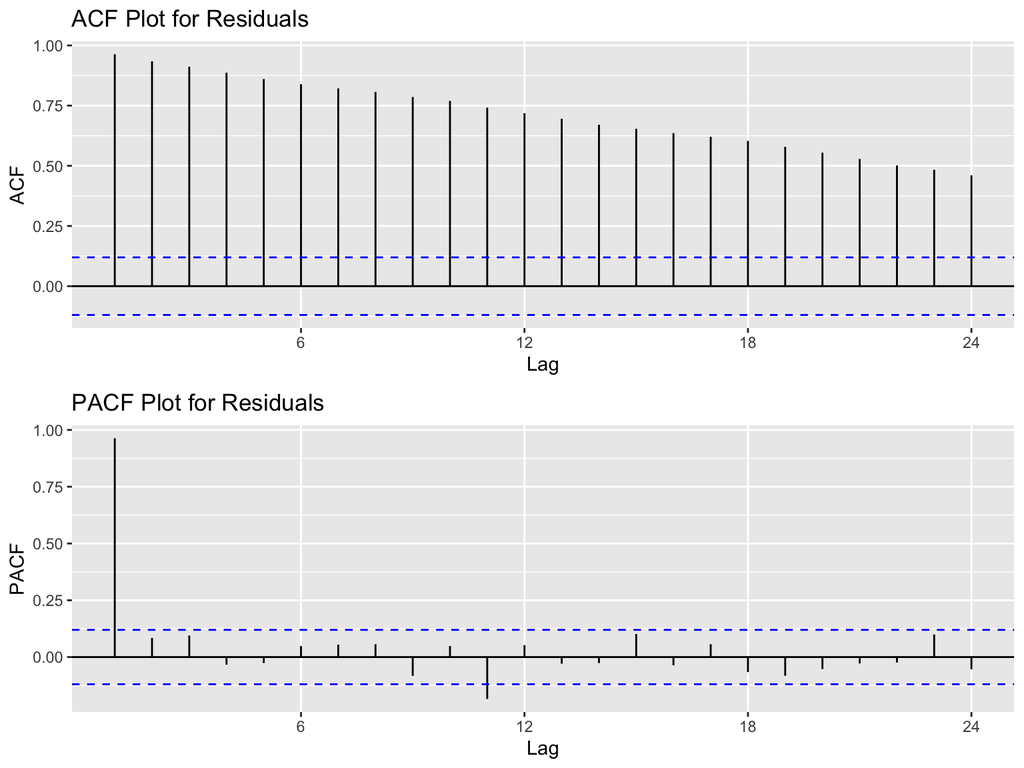

```r
res.fit <- ts(residuals(fit.reg),star=decimal_date(min_date),frequency = 12)

# ACF Plot
acf_plot <- ggAcf(res.fit, main="ACF Plot for Residuals")

# PACF Plot
pacf_plot <- ggPacf(res.fit, main="PACF Plot for Residuals")

# Arrange Plots
grid.arrange(acf_plot, pacf_plot, nrow=2)
```

### Differencing

The ACF plot provides a clear visual indication of high autocorrelation over most of the lags plotted. Recognizing the need for stationarity, the next critical step in our analysis is to perform differencing on the data. This process is performed to mitigate the observed autocorrelation patterns.

**First Ordinary Difference**

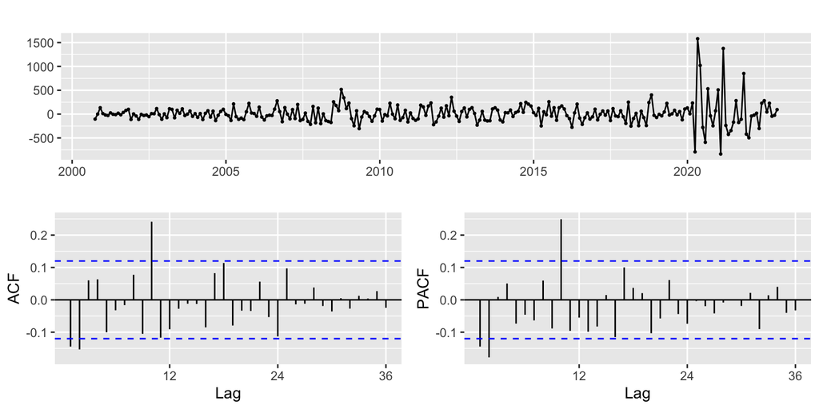

```r
# Ordinary Differencing
res.fit %>% diff() %>% ggtsdisplay()
```

### Model Parameters

$p = 2$

$d = 1$

$q = 2$

**Parameters**

**{r}**

```r
xt <- res.fit

# PACF plot parameter selection
p_value <- 3

# Number of differences
d_value <- 2

# ACF plot parameter selection
q_value <- 3

# Initialize variable
i <- 1

# Initialize variable
temp <- data.frame()

# Calculate number of rows
rows <- p_value*d_value*q_value

#
ls <- matrix(rep(NA,6*rows),nrow=rows)

# Parameter testing loop
for (p in 1:p_value+1)
{
  for(q in 1:q_value+1)
  {
    for(d in 1:d_value)
    {

      #if(p-1+d+q-1<=8) #usual threshold
      #{

        model<- Arima(xt,order=c(p-1,d-1,q-1),include.drift=TRUE)
        ls[i,]= c(p-1,d-1,q-1,model$aic,model$bic,model$aicc)
        i=i+1
        #print(i)

      #}

    }
  }
}

temp <- as.data.frame(ls)

names(temp) <- c("p","d","q","AIC","BIC","AICc")

#temp
#knitr::kable(temp)
```

**{r}**

```r
# Check best model with AIC
temp[which.min(temp$AIC),]
```

```
   p d q      AIC     BIC    AICc
18 3 1 3 3648.782 3677.48 3649.34
```

**{r}**

```r
# Check best model with BIC
temp[which.min(temp$BIC),]
```

```
  p d q      AIC      BIC     AICc
2 1 1 1 3651.129 3665.478 3651.282
```

**{r}**

```r
# Check best model with AICc
temp[which.min(temp$AICc),]
```

```
   p d q      AIC     BIC    AICc
18 3 1 3 3648.782 3677.48 3649.34
```

**auto.arima()**

**{r}**

```r
# Assign the exogenous variable
xreg <- dd.ts[, "oil_price"]

fit_auto_arima <- auto.arima(dd.ts[, "bicycles"], xreg = xreg)

summary(fit_auto_arima)
```

```
Series: dd.ts[, "bicycles"]
Regression with ARIMA(2,1,4)(0,0,2)[12] errors

Coefficients:
          ar1     ar2      ma1     ma2     ma3     ma4     sma1     sma2
      -0.0572  0.8161  -0.1835  -1.111  0.1595  0.3496  -0.2124  -0.0965
s.e.   0.0960  0.0943   0.1083   0.090  0.0691  0.0652   0.0656   0.0649
        drift     xreg
      15.4840  76.4995
s.e.   6.9269  45.8231

sigma^2 = 33191:  log likelihood = -1768.69
AIC=3559.39   AICc=3560.42   BIC=3598.85

Training set error measures:
                     ME     RMSE      MAE        MPE     MAPE      MASE
Training set -0.2957905 181.5016 87.29142 -0.1562903 1.785768 0.3087384
                     ACF1
Training set -0.008084968
```

### Model Diagnostics

The evaluation of the model selection criteria shows a consistent preference for the (3,1,3) model by AIC and AICc, while BIC was found to minimize the (1,1,1) model.

**AIC**

**Model Diagnostics - parameters with best AIC**

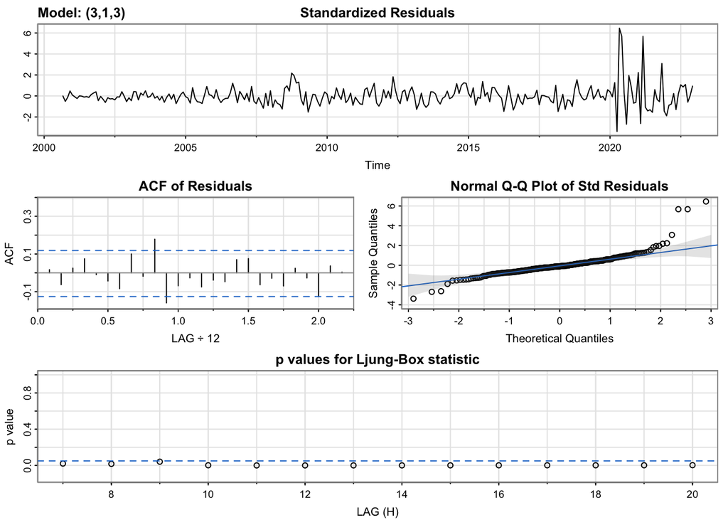

```r
AIC <- temp[which.min(temp$AIC),]

p1 <- AIC$p
d1 <- AIC$d
q1 <- AIC$q

# Model diagnostics for best AIC
model_output <- capture.output(sarima(xt, p1, d1, q1))
```

**BIC**

**Model Diagnostics - parameters with best BIC**

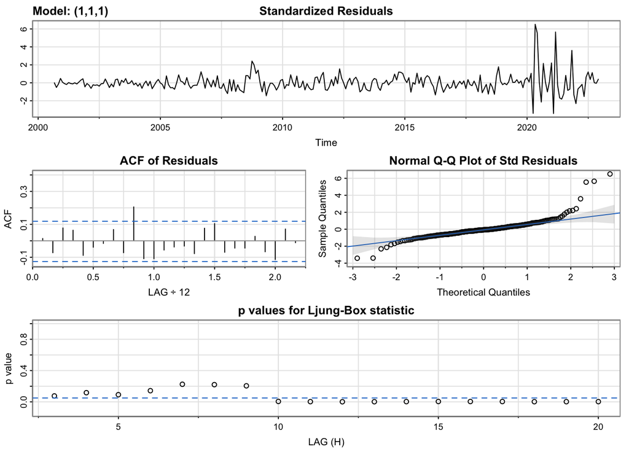

```r
BIC <- temp[which.min(temp$BIC),]

p2 <- BIC$p
d2 <- BIC$d
q2 <- BIC$q

# Model diagnostics for best BIC
model_output <- capture.output(sarima(xt, p2, d2, q2))
```

### Fit Model

We can observe that there should be an accurate predictive model as the fit model is very close together wiht the original data.

**Model Fit Plot**

**Model Fitting**

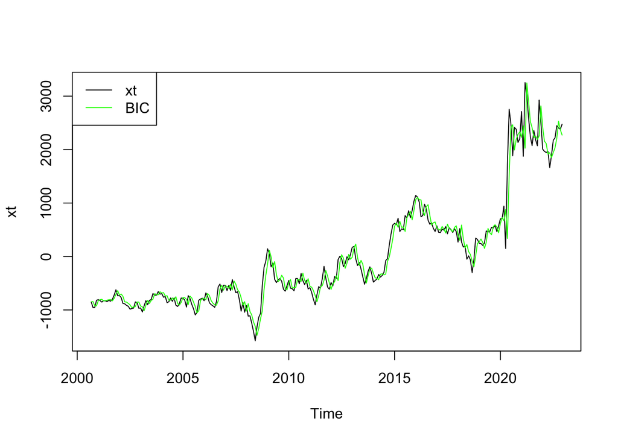

```r
best_model <- temp[which.min(temp$AIC),]

p <- best_model$p
d <- best_model$d
q <- best_model$q


model <- Arima(xt,order=c(p, d, q),include.drift = TRUE)

plot(xt, col="black")
lines(fitted(model), col="green")
legend(x = "topleft", legend = c("xt", "BIC"), col = c("black", "green"), lty = 1)
```

**Model Summary**

**Fitted Model Summary**

```r
fit <- Arima(xt, order=c(p, d, q))
summary(fit)
```

```
Series: xt
ARIMA(3,1,3)

Coefficients:
         ar1      ar2     ar3      ma1     ma2      ma3
      0.2601  -0.8479  0.5002  -0.4368  0.8679  -0.6424
s.e.  0.2544   0.0679  0.2507   0.2272  0.0532   0.2271

sigma^2 = 48065:  log likelihood = -1817.27
AIC=3648.54   AICc=3648.98   BIC=3673.66

Training set error measures:
                   ME     RMSE      MAE       MPE     MAPE      MASE      ACF1
Training set 17.16287 216.3545 135.4776 -3.245212 58.08572 0.3211183 0.0126856
```

### Forecast Plot

The final version of the model is an ARIMA (3, 1, 3) model. The forecast plot shows that ther will be very low fluctutuations and no trend at all. For future analysis we should make modifications or explore more complex models in order to make decisinos.

**{r}**

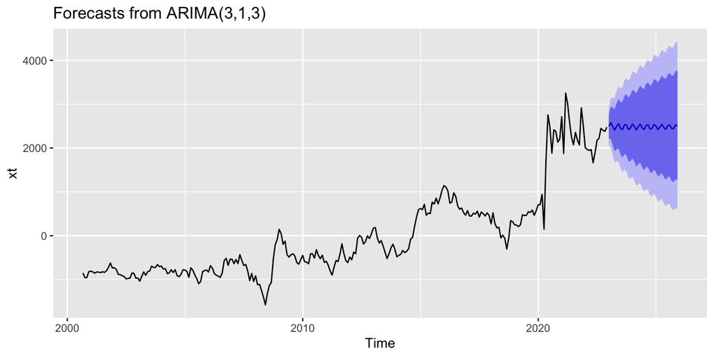

```r
forecast_fit <- forecast(fit,36)

# Path to save plot
file_path <- "../images/7_bicycles.png"

# Plot
plot <- autoplot(forecast_fit)

# Use ggsave to save the plot as a PNG image
ggsave(plot, filename = file_path, width = 10, height = 5)

# Show plot
plot
```

### Benchmark Models

**Benchmark Models Plot**

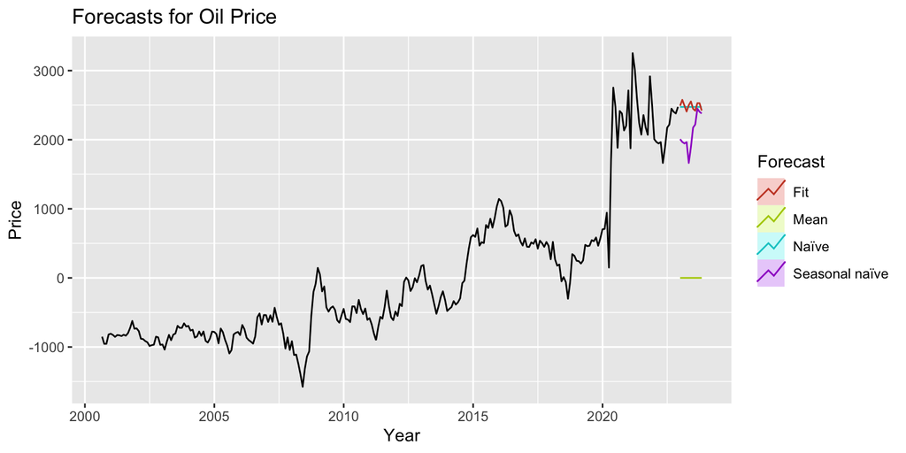

```r
autoplot(xt) +
  autolayer(meanf(xt, h=11),
            series="Mean", PI=FALSE) +
  autolayer(naive(xt, h=11),
            series="Naïve", PI=FALSE) +
  autolayer(snaive(xt, h=11),
            series="Seasonal naïve", PI=FALSE) +
  autolayer(forecast(forecast_fit, h=11),
            series="Fit", PI=FALSE) +
  ggtitle("Forecasts for Oil Price") +
  xlab("Year") + ylab("Price") +
  guides(colour=guide_legend(title="Forecast"))
```